# Markdown für Stadtsoziologie

Jonas Mellein

9 5 2022

# Datenaufbereitung

## 1. Packages installieren und Arbeitsordner definieren

```r
install.packages("tidyverse", repos = "http://cran.us.r-project.org")
library(tidyverse)
install.packages("readr", repos = "http://cran.us.r-project.org")
library(readr)
install.packages("geojsonsf", repos = "http://cran.us.r-project.org")
library(geojsonsf)
install.packages("osmdata", repos = "http://cran.us.r-project.org")
library(osmdata)
install.packages("sf", repos = "http://cran.us.r-project.org")
library(sf)


#### Hier unkommentiert, da jeweils auf den PC anzupassen ist, wo die Daten liegen
#setwd("d:/stadtsoz_karlsruhe/neosatz")
```

## 2. Datensätze einlesen, bearbeiten & öffnen

```r
migration <- read_csv("D:/stadtsoz_karlsruhe/neosatz/migration.csv")
colnames(migration)[4] <- "DeuMitMigh"
colnames(migration)[5] <- "Ausländer"
u18mig <- read.csv("D:/stadtsoz_karlsruhe/neosatz/migration-unter-18-jahrige-mit-migrationshintergrund-nach-art.csv")
colnames(u18mig)[3] <- "U18_Personen"
colnames(u18mig)[4] <- "U18_DeuMitMigh"
colnames(u18mig)[5] <- "U18_Ausländer"
gesamt <- read.csv("D:/stadtsoz_karlsruhe/neosatz/klassenstufe4-insgesamt.csv")
colnames(gesamt)[3] <- "Übergänge_gesamt"
gymn <- read.csv("D:/stadtsoz_karlsruhe/neosatz/gymnasien.csv")
colnames(gymn)[3] <- "Gymnasium"
geme <- read.csv("D:/stadtsoz_karlsruhe/neosatz/gemeinschaftsschulen.csv")
colnames(geme)[3] <- "Gemeinschaftsschule"
real <- read.csv("D:/stadtsoz_karlsruhe/neosatz/realschulen.csv")
colnames(real)[3] <- "Realschule"
haup <- read.csv("D:/stadtsoz_karlsruhe/neosatz/haupt-werkrealschulen.csv")
colnames(haup)[3] <- "HauptWerkrealschule"

view(migration)
view(u18mig)
view(gesamt)
view(gymn)
view(geme)
view(real)
view(haup)
```

## 3. Datensätze vereinen

Version 1: Da Gemeinschaftsschulen erst ab 2012 -> alle folgendenen Datensätze erst ab 2012 aufgenommen:

```r
mig2012 <- filter(migration, Jahr >= 2012)
u18mig2012 <- filter(u18mig, Jahr >= 2012)
gesamt2012 <- filter(gesamt, Jahr >=2012)
gym2012 <- filter(gymn, Jahr >= 2012)
gem2012 <- filter(geme, Jahr >= 2012)
rea2012 <- filter(real, Jahr >= 2012)
hau2012 <- filter(haup, Jahr >= 2012)

all_data2012 <- gesamt2012 %>%
  left_join(gym2012, by= c('Stadtteil', 'Jahr')) %>%
  left_join(gem2012, by= c('Stadtteil', 'Jahr')) %>%
  left_join(rea2012, by= c('Stadtteil', 'Jahr')) %>%
  left_join(hau2012, by= c('Stadtteil', 'Jahr')) %>%
  left_join(mig2012, by= c('Stadtteil', 'Jahr')) %>%
  left_join(u18mig2012, by= c('Stadtteil', 'Jahr'))
```

Vereinten 2012-2021 Datensatz anzeigen lassen:

```r
view(all_data2012)
```

Version 2: Ohne Gemeinschaftsschulen und Daten ab 2010:

```r
mig2010 <- filter(migration, Jahr >= 2010)
u18mig2010 <- filter(u18mig, Jahr >= 2010)
gesamt2010 <- filter(gesamt, Jahr >=2010)
gym2010 <- filter(gymn, Jahr >= 2010)
rea2010 <- filter(real, Jahr >= 2010)
hau2010 <- filter(haup, Jahr >= 2010)


all_data2010 <- gesamt2010 %>%
  left_join(gym2010, by= c('Stadtteil', 'Jahr')) %>%
  left_join(rea2010, by= c('Stadtteil', 'Jahr')) %>%
  left_join(hau2010, by= c('Stadtteil', 'Jahr')) %>%
  left_join(mig2010, by= c('Stadtteil', 'Jahr'))
```

Vereinten 2010-2021 Datensatz anzeigen lassen:

```r
view(all_data2010)
```

# Korrelationen & Zusammenhänge:

## 1. Nur 2021 Zusammenhänge

### 1.1. Aus 2012er Datensatz das Jahr 2021 filtern:

```r
Kor2021 <- filter(all_data2012, Jahr == 2021)
```

### 1.2. Diverse Zusammenhänge mit cor() Befehl (= Pearson)

-> über ganz Karlsruhe:

Zusammenhang zwischen Anteil der Schülerinnen und Schüler, die 2021 auf ein Gymnasium wechseln und der Anzahl Personen mit Migrationshintergrund in ganz Karlsruhe”:

```r
cor(Kor2021$Gymnasium, Kor2021$Personen, use = "complete.obs",
    method = "pearson")
```

```
## [1] 0.0823467
```

```r
#missings rausschmeissen mit complete.obs
```

Visuelle Darstellung

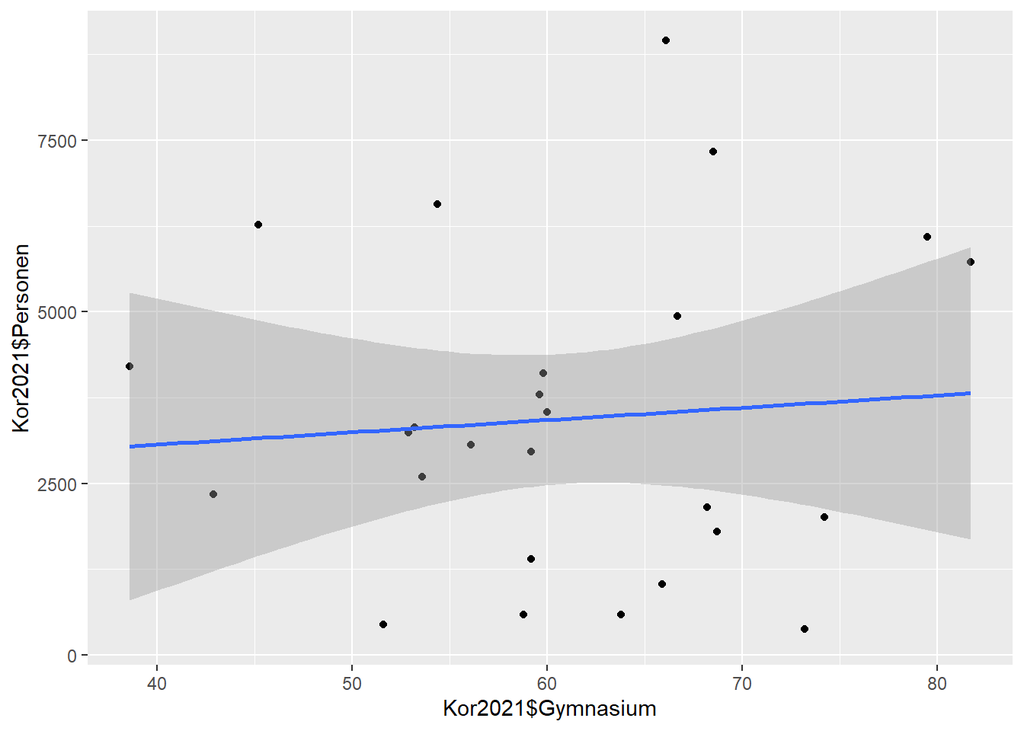

```r
ggplot(Kor2021, aes(x=Kor2021$Gymnasium, y=Kor2021$Personen)) +
  geom_point() +
  geom_smooth(method=lm)
```

Zusammenhang zwischen Anteil der Schülerinnen und Schüler, die 2021 auf eine Gemeinschaftsschule wechseln und der Anzahl Personen mit Migrationshintergrund in ganz Karlsruhe:

```r
cor(Kor2021$Gemeinschaftsschule , Kor2021$Personen, use = "complete.obs",
    method = "pearson")
```

```
## [1] -0.1425934
```

Visuelle Darstellung

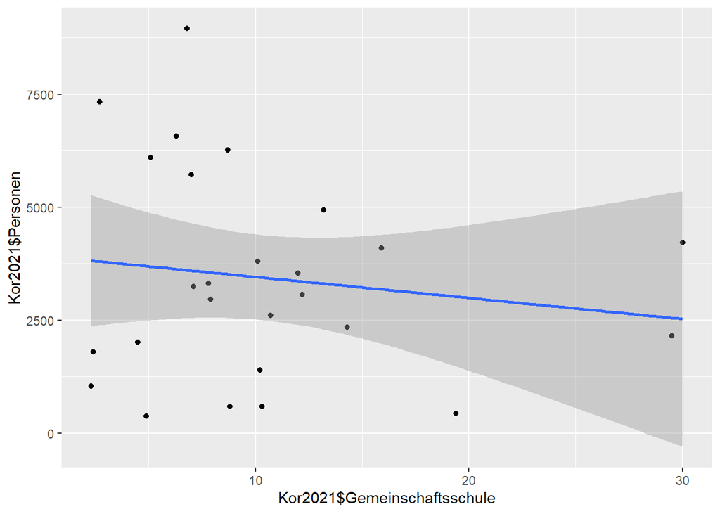

```r
ggplot(Kor2021, aes(x=Kor2021$Gemeinschaftsschule, y=Kor2021$Personen)) +
  geom_point() +
  geom_smooth(method=lm)
```

Zusammenhang zwischen Anteil der Schülerinnen und Schüler, die 2021 auf eine Realschule wechseln und der Anzahl Personen mit Migrationshintergrund in ganz Karlsruhe:

```r
cor(Kor2021$Realschule , Kor2021$Personen, use = "complete.obs",
    method = "pearson")
```

```
## [1] -0.1464027
```

Visuelle Darstellung

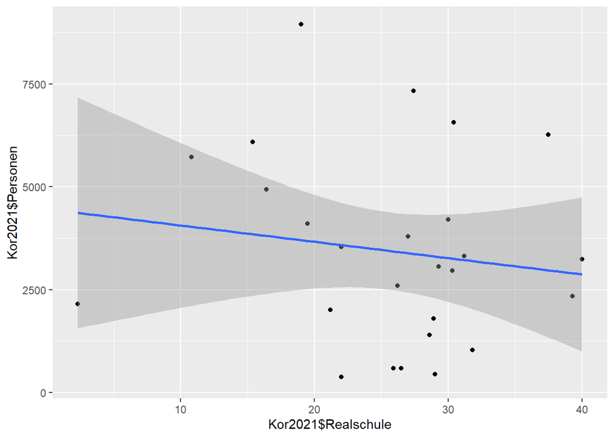

```r
ggplot(Kor2021, aes(x=Kor2021$Realschule, y=Kor2021$Personen)) +
  geom_point() +
  geom_smooth(method=lm)
```

Zusammenhang zwischen Anteil der Schülerinnen und Schüler, die 2021 auf eine Haupt-/Werkrealschule wechseln und der Anzahl Personen mit Migrationshintergrund in ganz Karlsruhe:

```r
cor(Kor2021$HauptWerkrealschule, Kor2021$Personen, use = "complete.obs",
    method = "pearson")
```

```
## [1] 0.3433011
```

Visuelle Darstellung

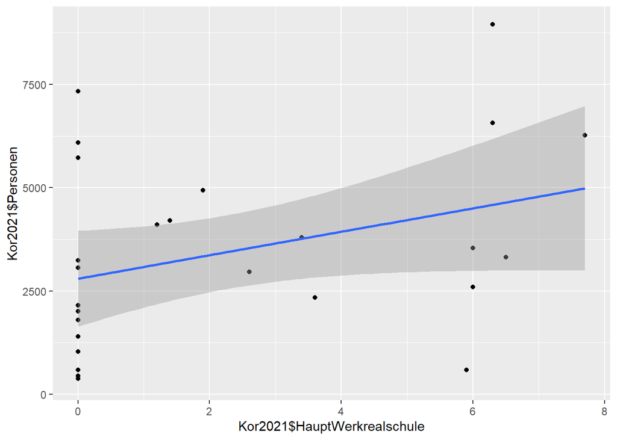

```r
ggplot(Kor2021, aes(x=Kor2021$HauptWerkrealschule, y=Kor2021$Personen)) +
  geom_point() +
  geom_smooth(method=lm)
```

## 2. Stadtteilbetrachtung

-> einzelne Stadtteile über Jahre:

### NEUREUT (Vorstadt, am Stadtrand Beispiel)

Zusammenhang zwischen Anteil der Schülerinnen und Schüler, die in von 2012 bis 2021 auf … wechseln und der Anzahl Personen mit Migrationshintergrund in Neureut:

```r
neureut_all <- filter(all_data2012, Stadtteil == "Neureut")

cor(neureut_all$Gymnasium , neureut_all$Personen, use = "complete.obs",
    method = "pearson")
```

```
## [1] 0.564777
```

```r
cor(neureut_all$Gemeinschaftsschule , neureut_all$Personen, use = "complete.obs",
    method = "pearson")
```

```
## [1] 0.2642616
```

```r
cor(neureut_all$Realschule , neureut_all$Personen, use = "complete.obs",
    method = "pearson")
```

```
## [1] -0.4097592
```

```r
cor(neureut_all$HauptWerkrealschule , neureut_all$Personen, use = "complete.obs",
    method = "pearson")
```

```
## [1] -0.6002659
```

Visuelle Darstellung

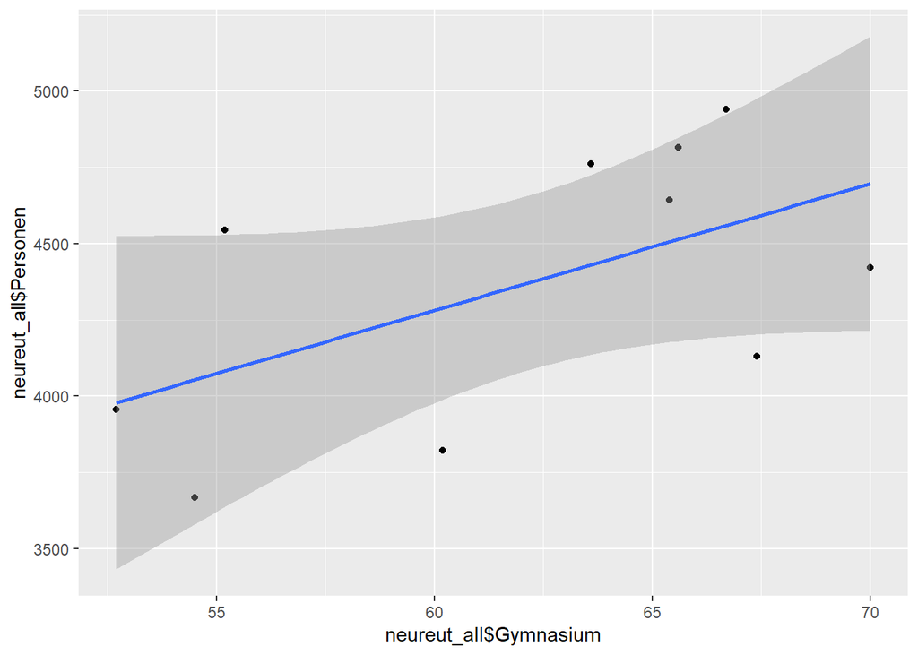

```r
ggplot(neureut_all, aes(x=neureut_all$Gymnasium, y=neureut_all$Personen)) +
  geom_point() +
  geom_smooth(method=lm)
```

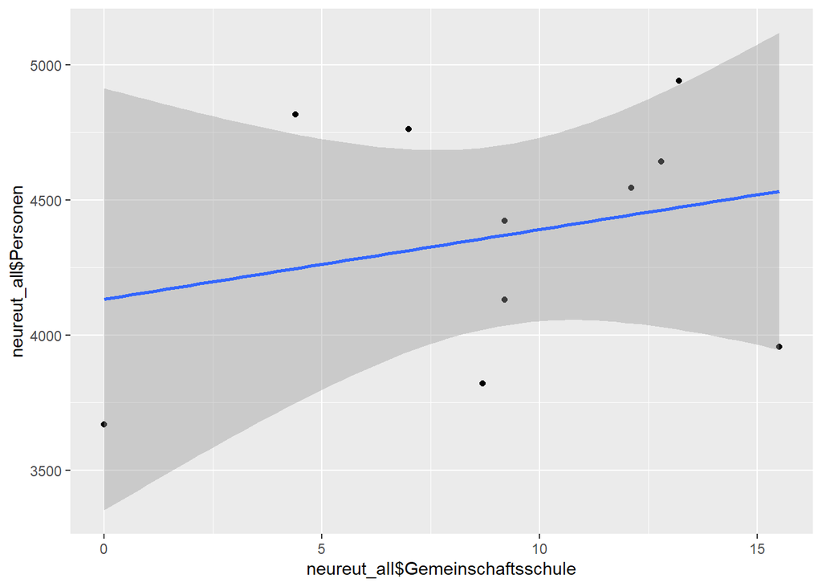

```r
ggplot(neureut_all, aes(x=neureut_all$Gemeinschaftsschule, y=neureut_all$Personen)) +
  geom_point() +
  geom_smooth(method=lm)
```

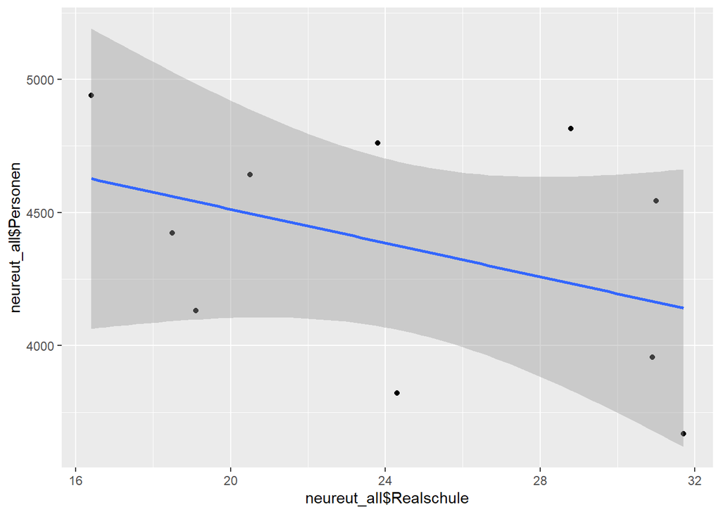

```r
ggplot(neureut_all, aes(x=neureut_all$Realschule, y=neureut_all$Personen)) +
  geom_point() +
  geom_smooth(method=lm)
```

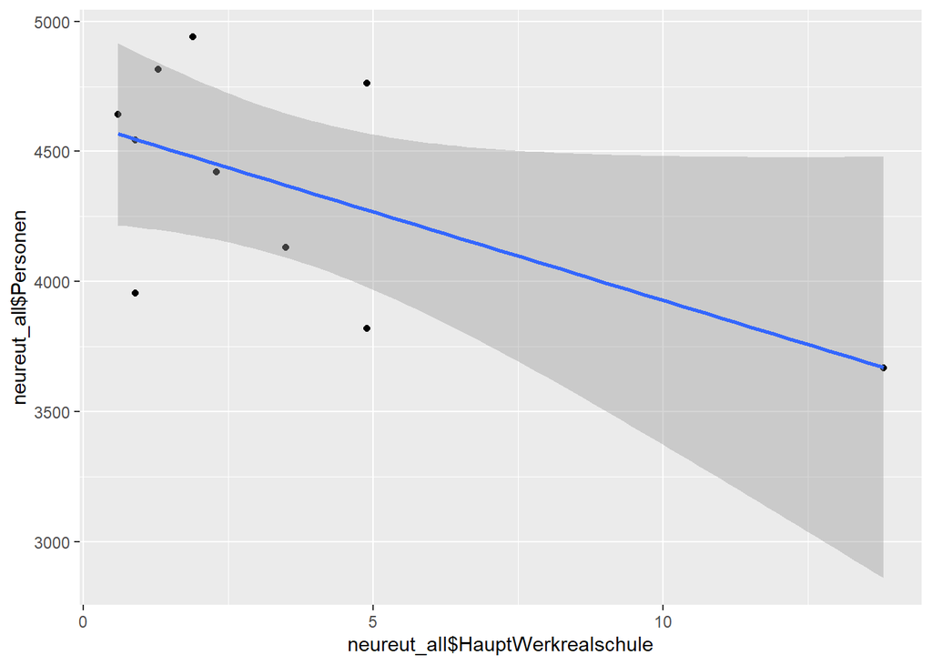

```r
ggplot(neureut_all, aes(x=neureut_all$HauptWerkrealschule, y=neureut_all$Personen)) +
  geom_point() +
  geom_smooth(method=lm)
```

### INNENSTADT-WEST (höchste Anzahl Straftaten 2021)

Zusammenhang zwischen Anteil der Schülerinnen und Schüler, die in von 2012 bis 2021 auf ….. wechseln und der Anzahl Personen mit Migrationshintergrund in der Innenstadt-West:

```r
innenwest_all <- filter(all_data2012, Stadtteil == "Innenstadt-West")

cor(innenwest_all$Gymnasium , innenwest_all$Personen, use = "complete.obs",
    method = "pearson")
```

```
## [1] 0.3389313
```

```r
cor(innenwest_all$Gemeinschaftsschule , innenwest_all$Personen, use = "complete.obs",
    method = "pearson")
```

```
## [1] 0.4293775
```

```r
cor(innenwest_all$Realschule , innenwest_all$Personen, use = "complete.obs",
    method = "pearson")
```

```
## [1] -0.4170681
```

```r
cor(innenwest_all$HauptWerkrealschule , innenwest_all$Personen, use = "complete.obs",
    method = "pearson")
```

```
## [1] -0.4405959
```

Visuelle Darstellung

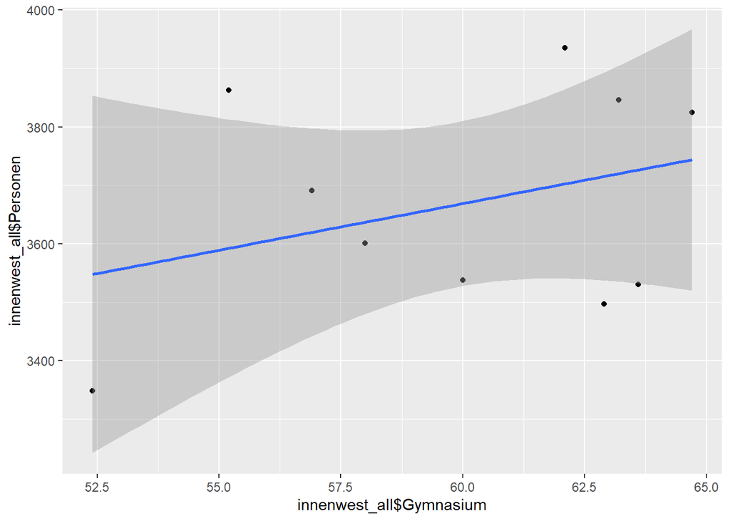

```r
ggplot(innenwest_all, aes(x=innenwest_all$Gymnasium, y=innenwest_all$Personen)) +
  geom_point() +
  geom_smooth(method=lm)
```

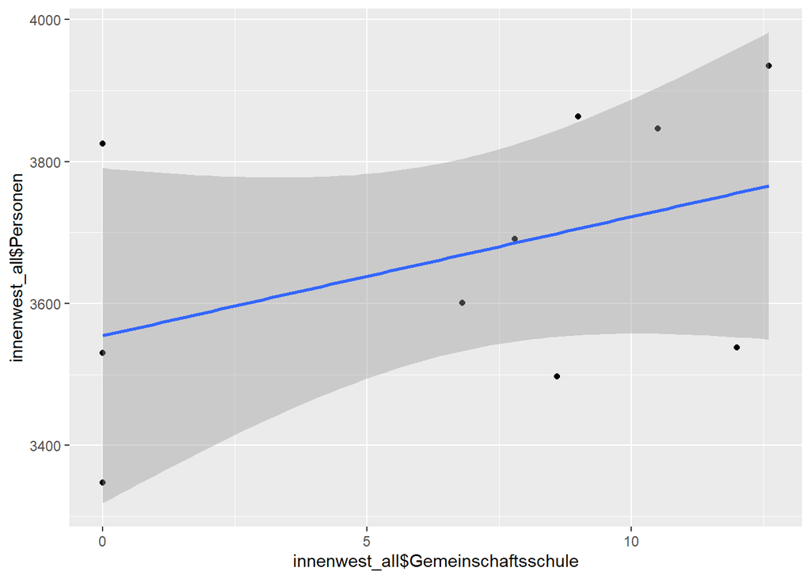

```r
ggplot(innenwest_all, aes(x=innenwest_all$Gemeinschaftsschule, y=innenwest_all$Personen)) +
  geom_point() +
  geom_smooth(method=lm)
```

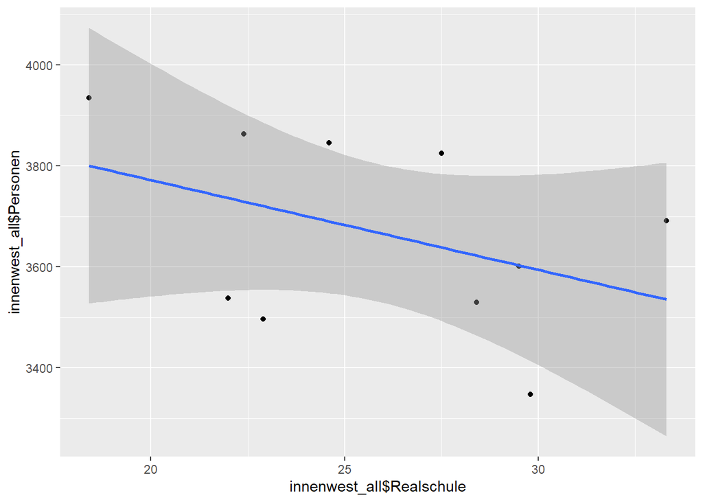

```r
ggplot(innenwest_all, aes(x=innenwest_all$Realschule, y=innenwest_all$Personen)) +
  geom_point() +
  geom_smooth(method=lm)
```

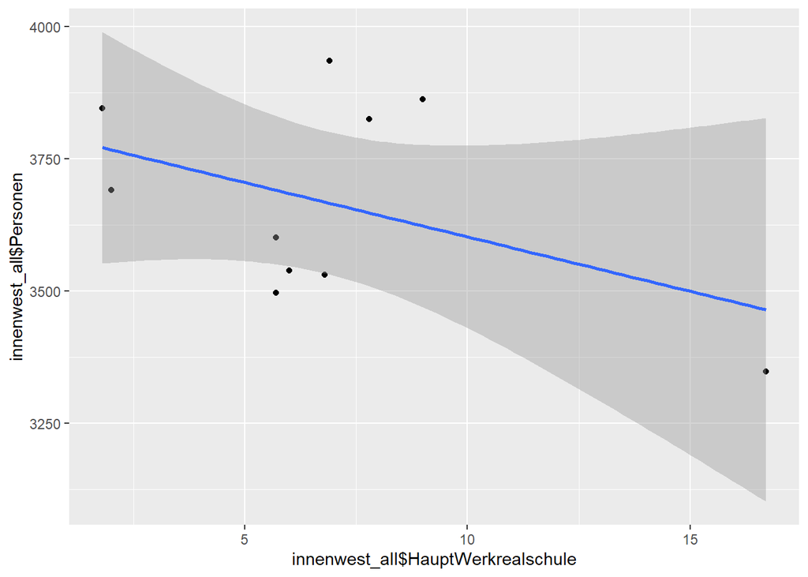

```r
ggplot(innenwest_all, aes(x=innenwest_all$HauptWerkrealschule, y=innenwest_all$Personen)) +
  geom_point() +
  geom_smooth(method=lm)
```

### DURLACH (höchste Anzahl an Einwohner und auch Personen mit Migrationshintergrund)

Zusammenhang zwischen Anteil der Schülerinnen und Schüler, die in von 2012 bis 2021 auf ….. wechseln und der Anzahl Personen mit Migrationshintergrund in der Durlach:

```r
Durlach_all <- filter(all_data2012, Stadtteil == "Durlach")

cor(Durlach_all$Gymnasium , Durlach_all$Personen, use = "complete.obs",
    method = "pearson")
```

```
## [1] 0.3084513
```

```r
cor(Durlach_all$Gemeinschaftsschule , Durlach_all$Personen, use = "complete.obs",
    method = "pearson")
```

```
## [1] -0.5445303
```

```r
cor(Durlach_all$Realschule , Durlach_all$Personen, use = "complete.obs",
    method = "pearson")
```

```
## [1] 0.6836506
```

```r
cor(Durlach_all$HauptWerkrealschule , Durlach_all$Personen, use = "complete.obs",
    method = "pearson")
```

```
## [1] 0.0511071
```

Visuelle Darstellung

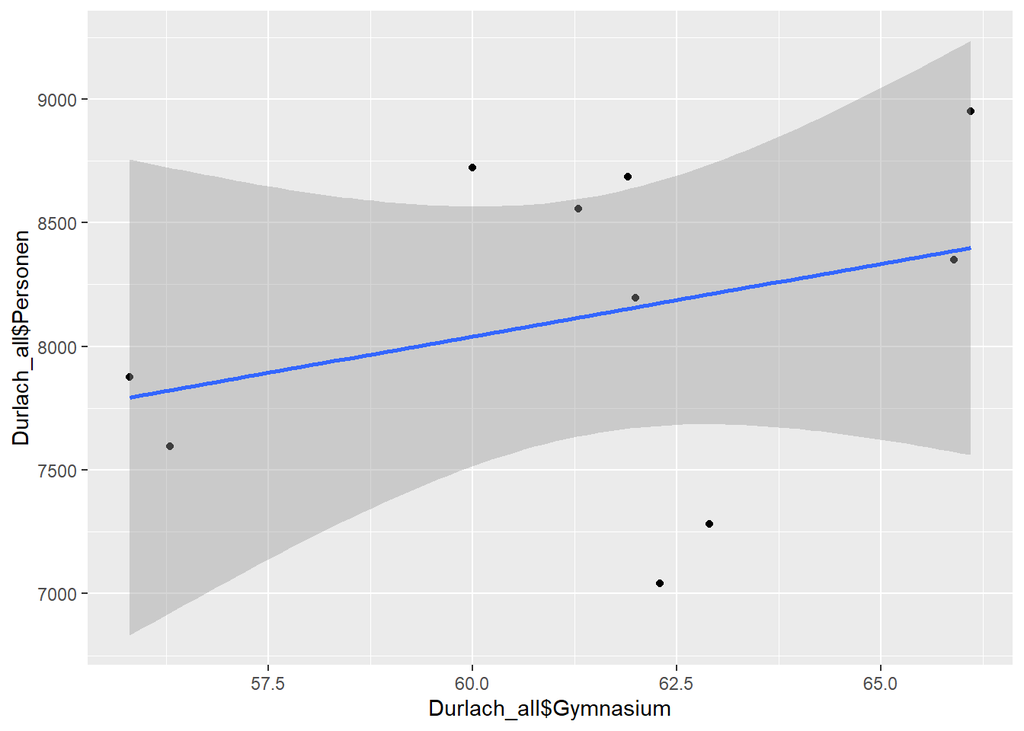

```r
ggplot(Durlach_all, aes(x=Durlach_all$Gymnasium, y=Durlach_all$Personen)) +
  geom_point() +
  geom_smooth(method=lm)
```

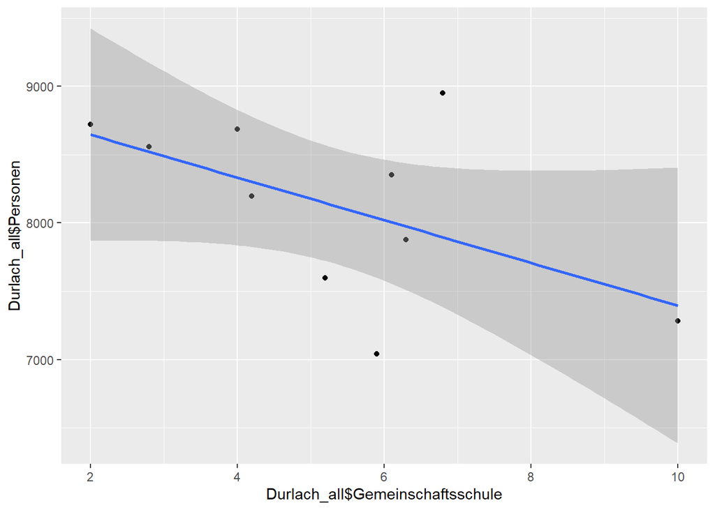

```r
ggplot(Durlach_all, aes(x=Durlach_all$Gemeinschaftsschule, y=Durlach_all$Personen)) +
  geom_point() +
  geom_smooth(method=lm)
```

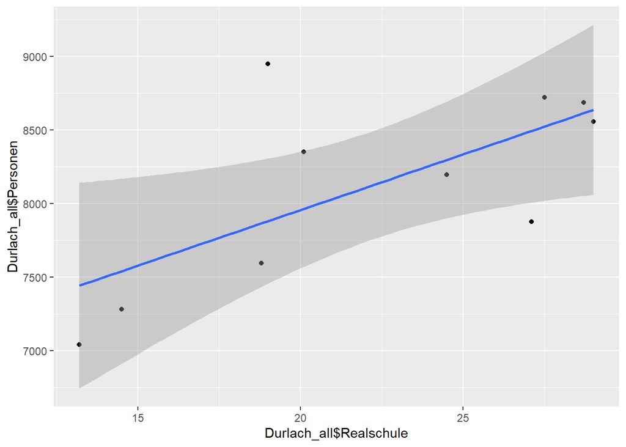

```r
ggplot(Durlach_all, aes(x=Durlach_all$Realschule, y=Durlach_all$Personen)) +
  geom_point() +
  geom_smooth(method=lm)
```

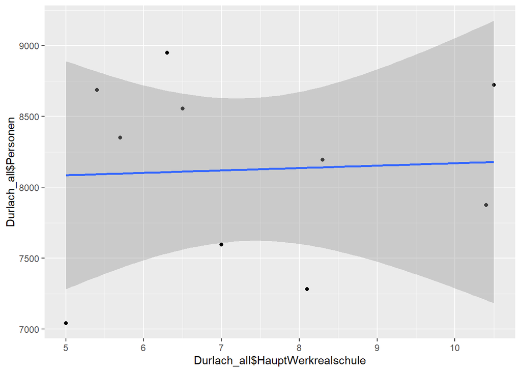

```r
ggplot(Durlach_all, aes(x=Durlach_all$HauptWerkrealschule, y=Durlach_all$Personen)) +
  geom_point() +
  geom_smooth(method=lm)
```

### INNENSTADT-OST (Höchster Migrantenanteil 48,3%)

Zusammenhang zwischen Anteil der Schülerinnen und Schüler, die in von 2012 bis 2021 auf ….. wechseln und der Anzahl Personen mit Migrationshintergrund in der Innenstadt-Ost:

```r
innenost_all <- filter(all_data2012, Stadtteil == "Innenstadt-Ost")

cor(innenost_all$Gymnasium , innenost_all$Personen, use = "complete.obs",
    method = "pearson")
```

```
## [1] -0.1327517
```

```r
cor(innenost_all$Gemeinschaftsschule , innenost_all$Personen, use = "complete.obs",
    method = "pearson")
```

```
## [1] 0.489325
```

```r
cor(innenost_all$Realschule , innenost_all$Personen, use = "complete.obs",
    method = "pearson")
```

```
## [1] 0.2441459
```

```r
cor(innenost_all$HauptWerkrealschule , innenost_all$Personen, use = "complete.obs",
    method = "pearson")
```

```
## [1] -0.6423923
```

Visuelle Darstellung

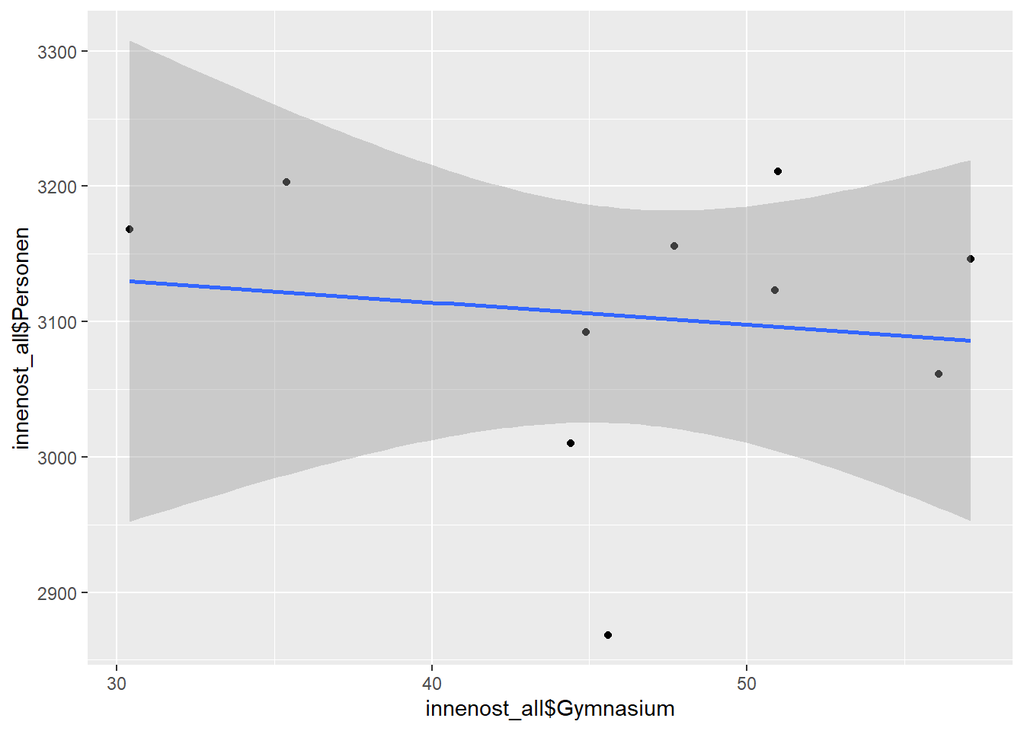

```r
ggplot(innenost_all, aes(x=innenost_all$Gymnasium, y=innenost_all$Personen)) +
  geom_point() +
  geom_smooth(method=lm)
```

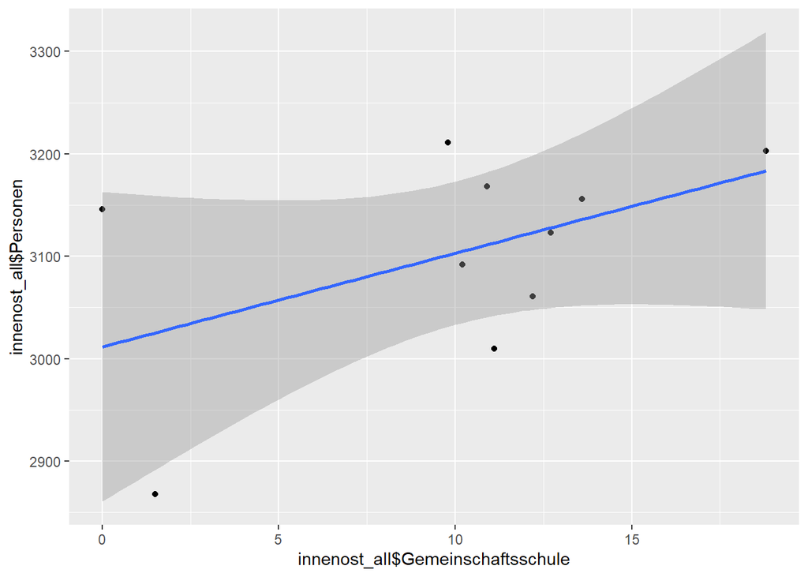

```r
ggplot(innenost_all, aes(x=innenost_all$Gemeinschaftsschule, y=innenost_all$Personen)) +
  geom_point() +
  geom_smooth(method=lm)
```

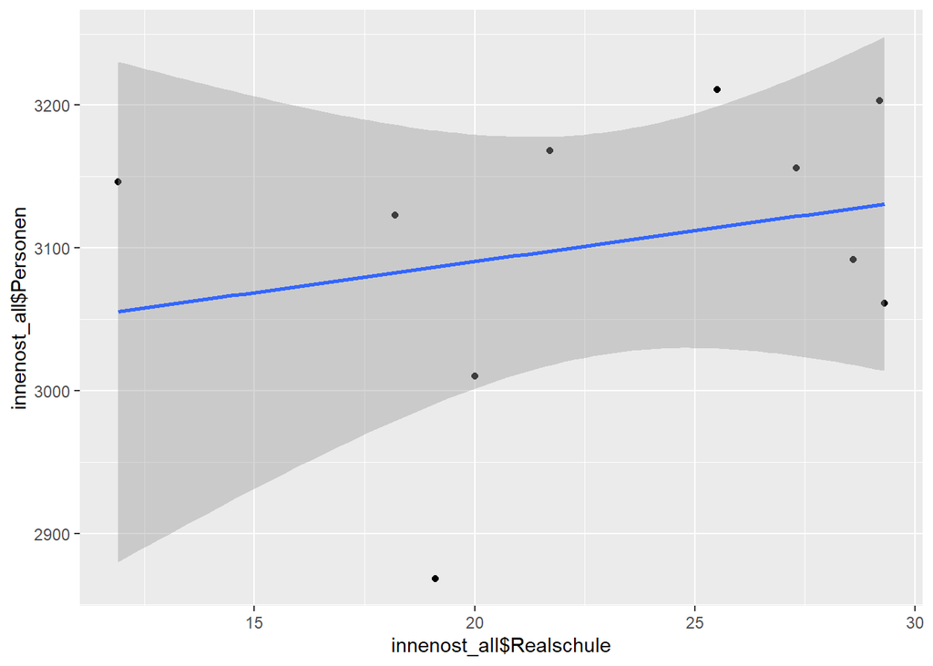

```r
ggplot(innenost_all, aes(x=innenost_all$Realschule, y=innenost_all$Personen)) +
  geom_point() +
  geom_smooth(method=lm)
```

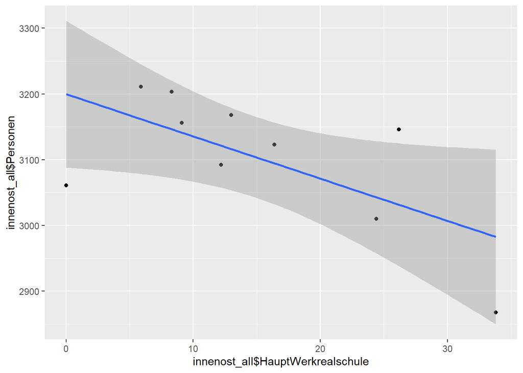

```r
ggplot(innenost_all, aes(x=innenost_all$HauptWerkrealschule, y=innenost_all$Personen)) +
  geom_point() +
  geom_smooth(method=lm)
```

### HOHENWETTERSBACH (geringster Migrantenanteil 12,7%)

Zusammenhang zwischen Anteil der Schülerinnen und Schüler, die in von 2012 bis 2021 auf ….. wechseln und der Anzahl Personen mit Migrationshintergrund in Hohenwettersbach:

```r
hohenw_all <- filter(all_data2012, Stadtteil == "Hohenwettersbach")

cor(hohenw_all$Gymnasium , hohenw_all$Personen, use = "complete.obs",
    method = "pearson")
```

```
## [1] 0.08214269
```

```r
cor(hohenw_all$Gemeinschaftsschule , hohenw_all$Personen, use = "complete.obs",
    method = "pearson")
```

```
## [1] 0.3291496
```

```r
cor(hohenw_all$Realschule , hohenw_all$Personen, use = "complete.obs",
    method = "pearson")
```

```
## [1] 0.09846936
```

```r
cor(hohenw_all$HauptWerkrealschule , hohenw_all$Personen, use = "complete.obs",
    method = "pearson")
```

```
## [1] -0.3128116
```

Visuelle Darstellung

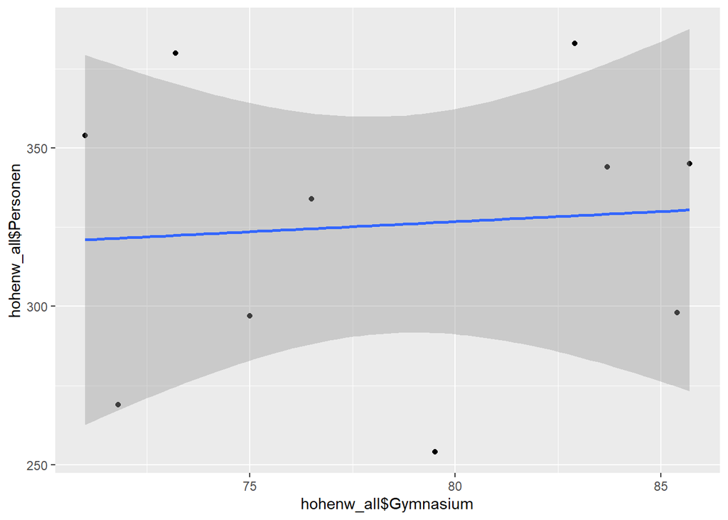

```r
ggplot(hohenw_all, aes(x=hohenw_all$Gymnasium, y=hohenw_all$Personen)) +
  geom_point() +
  geom_smooth(method=lm)
```

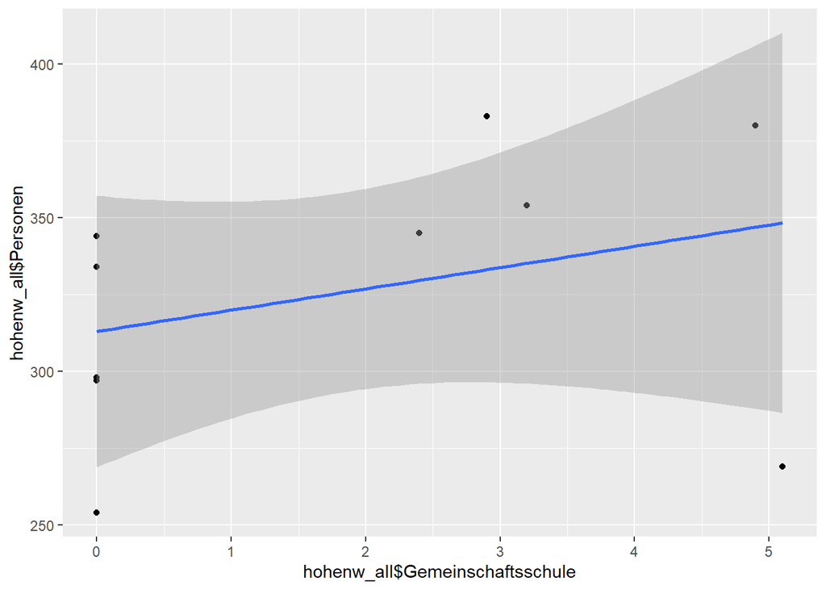

```r
ggplot(hohenw_all, aes(x=hohenw_all$Gemeinschaftsschule, y=hohenw_all$Personen)) +
  geom_point() +
  geom_smooth(method=lm)
```

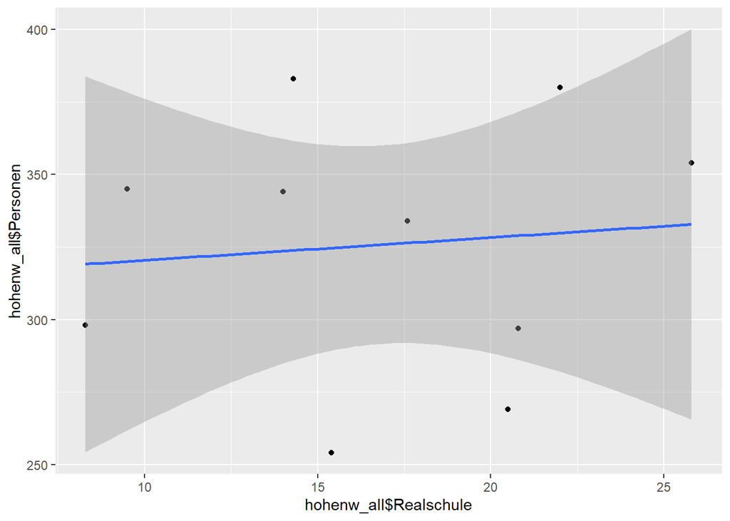

```r
ggplot(hohenw_all, aes(x=hohenw_all$Realschule, y=hohenw_all$Personen)) +
  geom_point() +
  geom_smooth(method=lm)
```

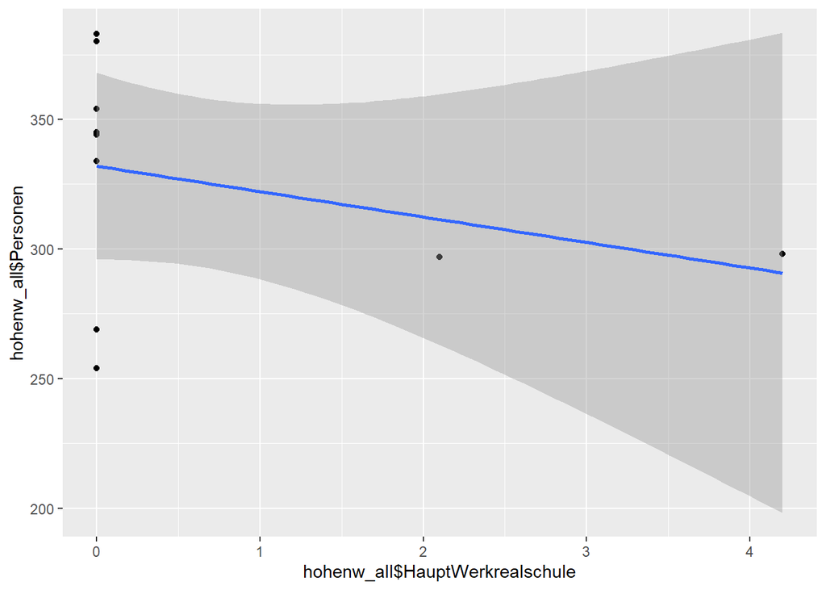

```r
ggplot(hohenw_all, aes(x=hohenw_all$HauptWerkrealschule, y=hohenw_all$Personen)) +
  geom_point() +
  geom_smooth(method=lm)
```

# Karten

## 1. Generelle Codierung

```r
KA_st <- c("Daxlanden","Grünwinkel","Mühlburg","Oberreut","Weststadt","Innenstadt-Ost","Innenstadt-West",
           "Durlach","Grötzingen","Hagsfeld","Oststadt","Rintheim", "Knielingen","Neureut","Nordstadt",
           "Nordweststadt","Waldstadt","Beiertheim-Bulach","Rüppurr","Südstadt","Südweststadt","Weiherfeld-Dammerstock",
           "Grünwettersbach","Hohenwettersbach","Palmbach","Stupferich","Wolfartsweier")

KA_sf <- getbb(paste("Karlsruhe", KA_st[1], sep = "-"),
               format_out = "sf_polygon")
for (i in 2:length(KA_st)) {
  KA_sf <- rbind(KA_sf,
                 getbb(paste("Karlsruhe", KA_st[i], sep = "-"),
                       format_out = "sf_polygon"))
}
KA_sf$place <- KA_st

colnames(KA_sf)[2] <- "Stadtteil"

view(KA_st)


KA_map <- full_join(Kor2021, KA_sf, copy = TRUE)
```

## 2. Karten

### 2.1 Menschen mit Migrationshintergrund in Karlsruhe 2021

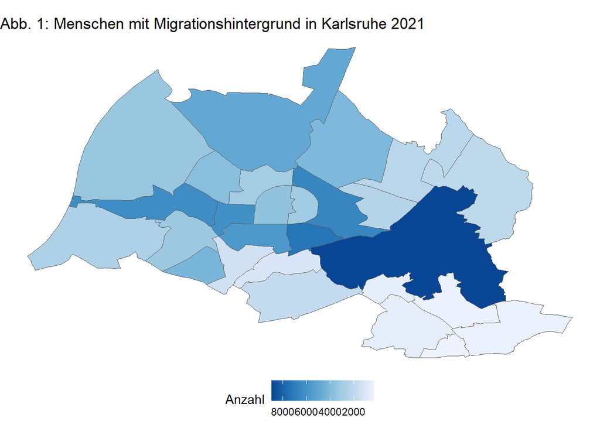

```r
ggplot(KA_map) +
  aes(fill = Personen,
      geometry = geometry) +
  geom_sf(size = 0.2) +
  theme_void() +
  theme(legend.position = "bottom",
        legend.direction = "horizontal") +
  scale_fill_distiller(trans = "reverse") +
  labs(title = "Abb. 1: Menschen mit Migrationshintergrund in Karlsruhe 2021",
       fill = "Anzahl")
```

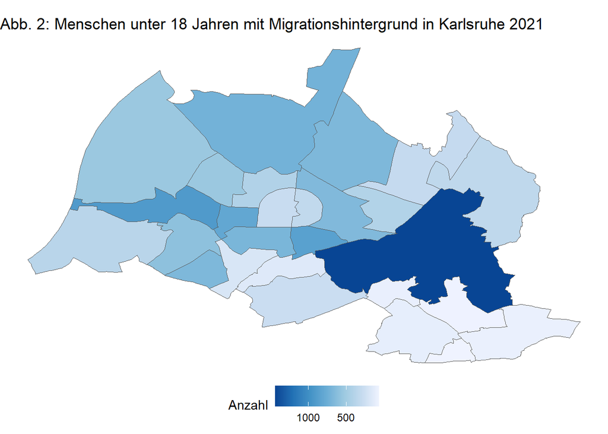

```r
colnames(KA_map)[11] <- "U18_Personen"

ggplot(KA_map) +
  aes(fill = U18_Personen,
      geometry = geometry) +
  geom_sf(size = 0.2) +
  theme_void() +
  theme(legend.position = "bottom",
        legend.direction = "horizontal") +
  scale_fill_distiller(trans = "reverse") +
  labs(title = "Abb. 2: Menschen unter 18 Jahren mit Migrationshintergrund in Karlsruhe 2021",
       fill = "Anzahl")
```

### 2.2 Übergänge auf weiterführende Schulen in Karlsruher Stadtteilen nach Schulart

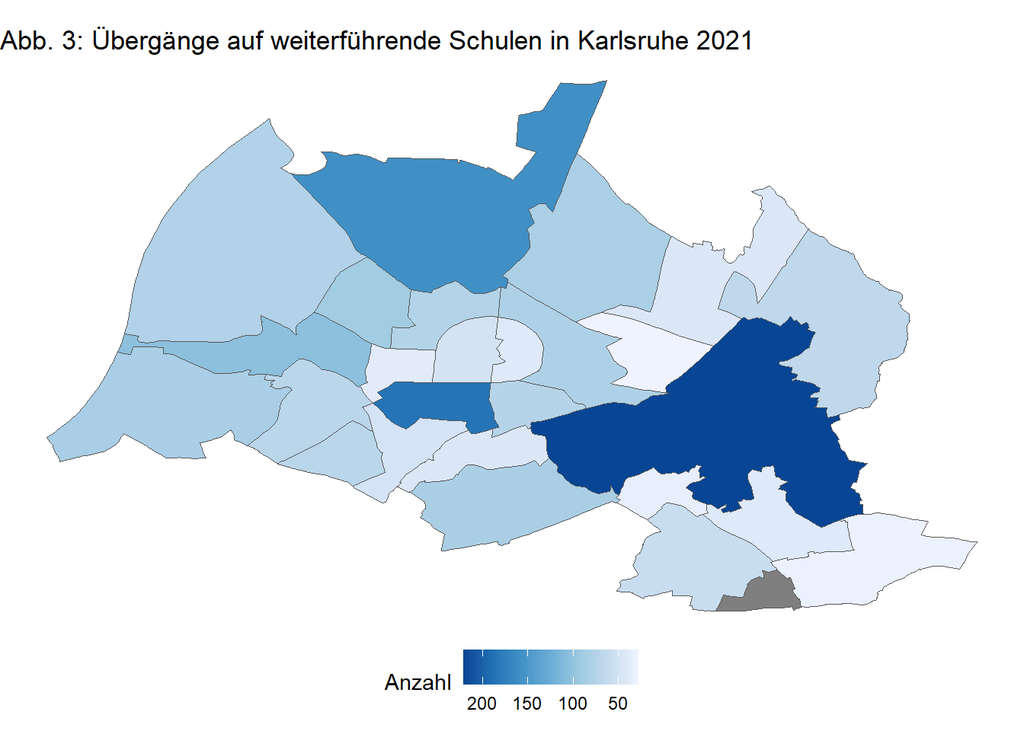

```r
# Übergänge gesamt

colnames(KA_map)[3] <- "Übergänge_gesamt"

ggplot(KA_map) +
  aes(fill = Übergänge_gesamt,
      geometry = geometry) +
  geom_sf(size = 0.2) +
  theme_void() +
  theme(legend.position = "bottom",
        legend.direction = "horizontal") +
  scale_fill_distiller(trans = "reverse") +
  labs(title = "Abb. 3: Übergänge auf weiterführende Schulen in Karlsruhe 2021",
       fill = "Anzahl")
```

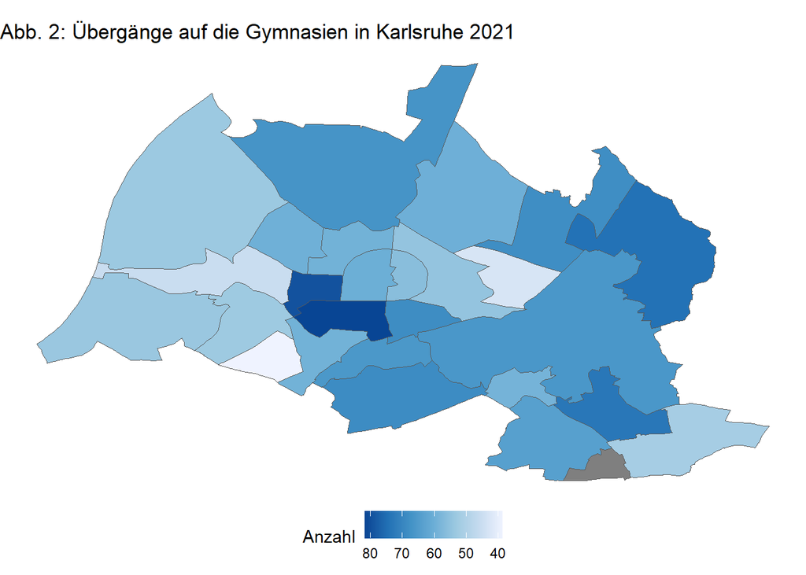

```r
# Gymnasium

ggplot(KA_map) +
  aes(fill = Gymnasium,
      geometry = geometry) +
  geom_sf(size = 0.2) +
  theme_void() +
  theme(legend.position = "bottom",
        legend.direction = "horizontal") +
  scale_fill_distiller(trans = "reverse") +
  labs(title = "Abb. 2: Übergänge auf die Gymnasien in Karlsruhe 2021",
       fill = "Anzahl")
```

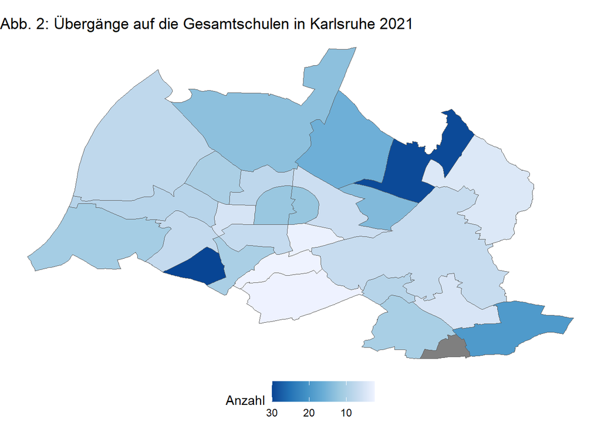

```r
# Gemeinschaftsschule

ggplot(KA_map) +
  aes(fill = Gemeinschaftsschule,
      geometry = geometry) +
  geom_sf(size = 0.2) +
  theme_void() +
  theme(legend.position = "bottom",
        legend.direction = "horizontal") +
  scale_fill_distiller(trans = "reverse") +
  labs(title = "Abb. 2: Übergänge auf die Gesamtschulen in Karlsruhe 2021",
       fill = "Anzahl")
```

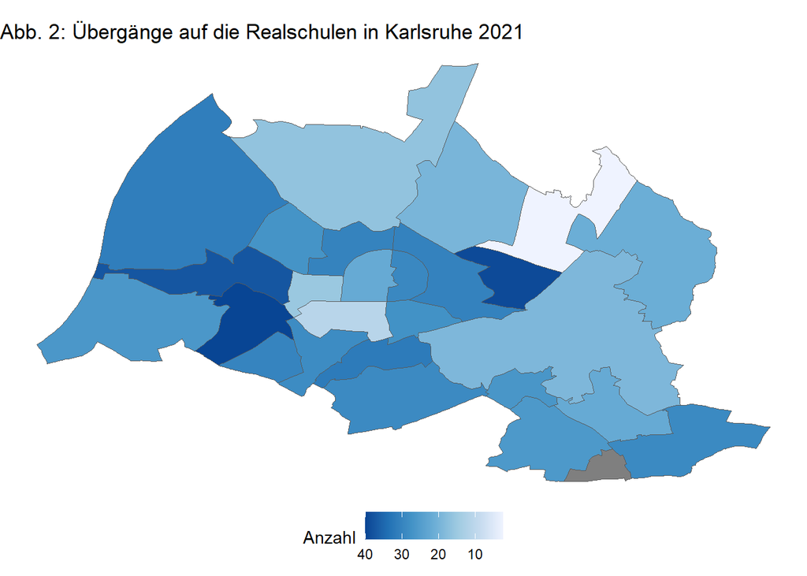

```r
# Realschule

ggplot(KA_map) +
  aes(fill = Realschule,
      geometry = geometry) +
  geom_sf(size = 0.2) +
  theme_void() +
  theme(legend.position = "bottom",
        legend.direction = "horizontal") +
  scale_fill_distiller(trans = "reverse") +
  labs(title = "Abb. 2: Übergänge auf die Realschulen in Karlsruhe 2021",
       fill = "Anzahl")
```

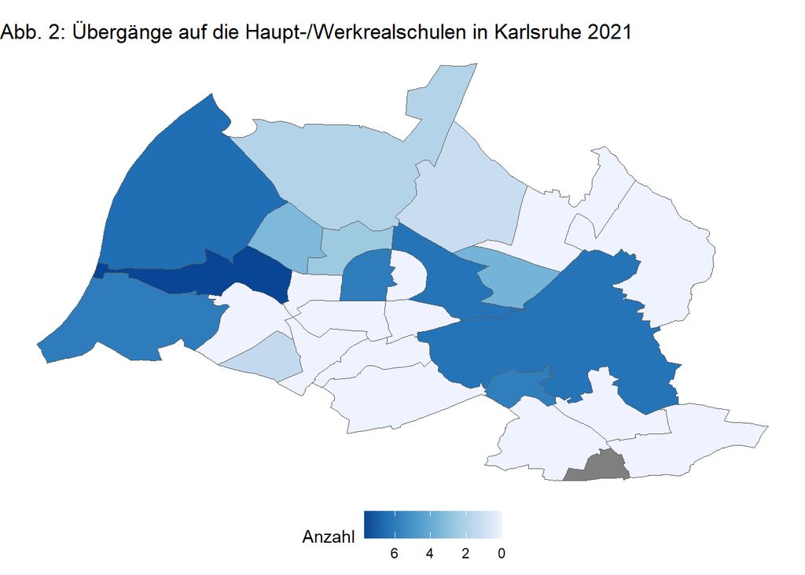

```r
# Haupt-/Werkrealschule

ggplot(KA_map) +
  aes(fill = HauptWerkrealschule,
      geometry = geometry) +
  geom_sf(size = 0.2) +
  theme_void() +
  theme(legend.position = "bottom",
        legend.direction = "horizontal") +
  scale_fill_distiller(trans = "reverse") +
  labs(title = "Abb. 2: Übergänge auf die Haupt-/Werkrealschulen in Karlsruhe 2021",
       fill = "Anzahl")
```